# Simulating a Mixture of Soil Colors

D.E. Beaudette

2021-02-04

# Background

The following code is only a *rough estimation* of mixing soil material and not a physically-based model of subtractive mixing of pigments. [We will get there eventually](https://github.com/ncss-tech/aqp/issues/10).

# Example

Required packages, be sure to ge the [latest versions from GitHub](https://github.com/ncss-tech/aqp).

```r
library(aqp)
library(soilDB)
```

Pick some colors and assign weights:

`60% 10YR 3/5` + `30% 5YR 5/6` + `10% 2.5Y 5/6` = **?**.

The `parseMunsell` function is used 3 times to:

1. split Munsell notation into hue/value/chroma components
2. convert to sRGB / CIELAB coordinates
3. convert to sRGB hex notation.

```r
colors <- c('10YR 3/5', '5YR 5/6', '2.5Y 5/6')
weights <- c(60, 30, 10)

# combine into a data.frame and convert to sRGB + CIE LAB
d <- cbind(
  parseMunsell(colors, convertColors=FALSE),
  parseMunsell(colors, return_triplets=TRUE, returnLAB=TRUE),
  pct=weights,
  col=parseMunsell(colors, convertColors=TRUE)
)

d
```

```
##    hue value chroma         r         g          b        L         A        B pct       col
## 1 10YR     3      5 0.3817539 0.2599868 0.09323485 30.81482  9.000702 30.27227  60 #614218FF
## 2  5YR     5      6 0.6516906 0.4320947 0.27623886 51.63431 18.064255 31.11055  30 #A66E46FF
## 3 2.5Y     5      6 0.5907267 0.4641984 0.19181078 51.65941  4.903976 41.89806  10 #977631FF
```

Estimate mixture via weighted average in CIELAB color space. This is a nearly-perceptual color system so the weighted average is a *reasonable* estimate. Again, this is not as accurate as subtractive mixing of pigments via spectral data.

```r
(mx <- estimateColorMixture(d, wt = 'pct', backTransform = TRUE))
```

```
##        r       g       b colorhue colorvalue colorchroma    sigma
## 1 0.4812 0.33025 0.15697     10YR          4           5 2.637697
```

```r
mx.munsell <- sprintf("%s %s/%s", mx$colorhue, mx$colorvalue, mx$colorchroma)
```

`60% 10YR 3/5` + `30% 5YR 5/6` + `10% 2.5Y 5/6` = 10YR 4/5.

## Visualization Ideas

Demonstrate mixing soil colors in CIE LAB color spaces via `estimateColorMixture()`.

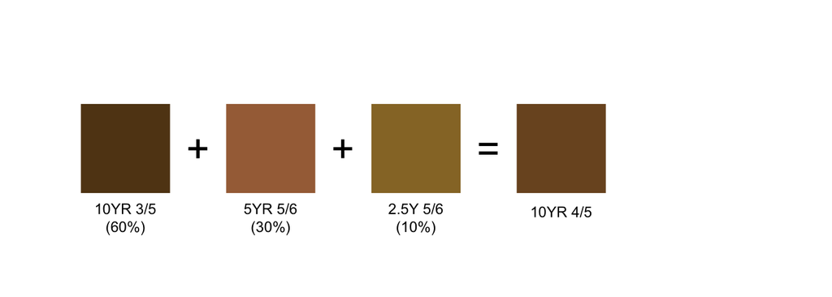

```r
mixColorDemo <- function(x) {
  x <- x[order(x$pct, decreasing = TRUE), ]
  n.cols <- nrow(x)
  x.vals <- 1:n.cols
  y.vals <- rep(0, times=n.cols)
  cols <- rgb(x[, c('r', 'g', 'b')])
  col.txt <- paste0(x$hue, ' ', x$value , '/', x$chroma, '\n(', x$pct, '%)')

  plot(x.vals, y.vals, col=cols, pch=15, cex=10, axes=FALSE, ylab='', xlab='', xlim=c(0.5, n.cols + 2.5))
  text(x.vals[-length(x.vals)] + 0.5, y.vals, '+', cex=2, lwd=2)
  text(max(x.vals) + 0.5, y.vals[1], '=', cex=2, lwd=2)

  text(x.vals, y.vals, col.txt, pos=1, offset=2.5, cex=0.75)

  # mix in CIELAB
  mixed.lab <- estimateColorMixture(x, wt = 'pct', backTransform = TRUE)

  # add mixed colors
  points(max(x.vals)+1, y.vals[1], col=rgb(mixed.lab[, c('r', 'g', 'b')]), cex=10, pch=15)
  col.txt <- paste0(mixed.lab$colorhue, ' ', mixed.lab$colorvalue , '/', mixed.lab$colorchroma)
  text(max(x.vals)+1, y.vals[1], col.txt, pos=1, offset=2.5, cex=0.75)
}


par(mar=c(1,1,1,1))
mixColorDemo(d)
```

### Alternative Representation

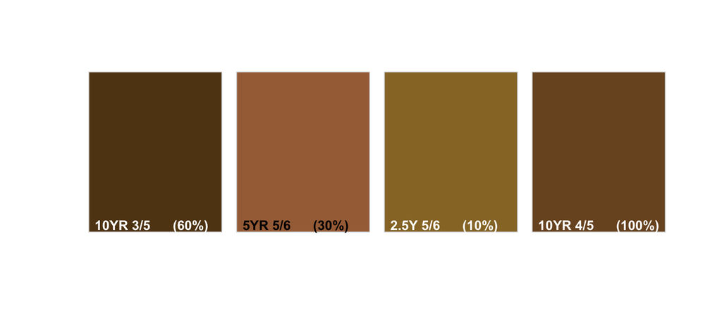

```r
# simulate mixture
mixed.lab <- estimateColorMixture(d, wt = 'pct', backTransform = TRUE)

# color vector
cols <- c(
  d$col,
  rgb(mixed.lab[, c('r', 'g', 'b')])
  )

# label vector
labs <- c(
  colors,
  paste0(mixed.lab$colorhue, ' ', mixed.lab$colorvalue , '/', mixed.lab$colorchroma)
)

# add weights
labs <- sprintf("%s      (%s%%)", labs, c(weights, 100))

# plot
soilPalette(
  colors = cols,
  lab = labs,
  lab.cex = 1
  )
```

# Mixing via Reference Spectra

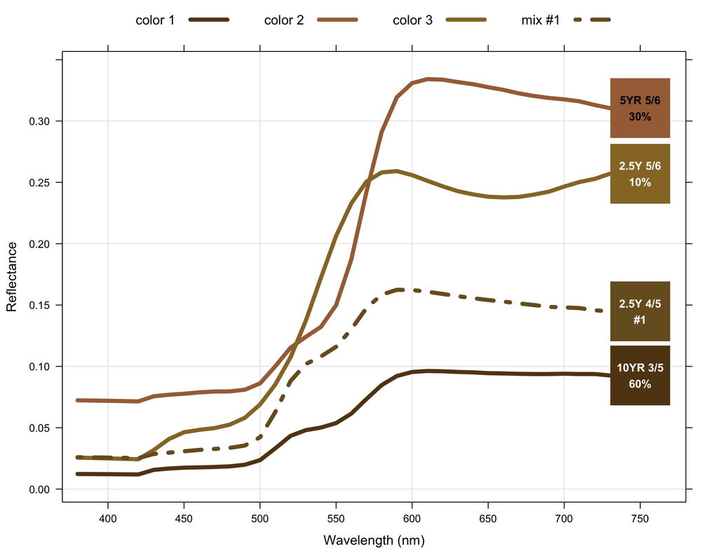

```r
colors <- c('10YR 3/5', '5YR 5/6', '2.5Y 5/6')
weights <- c(60, 30, 10)

plotColorMixture(x = colors, w = weights)
```

# Mix a Lot

This is very inefficient code.

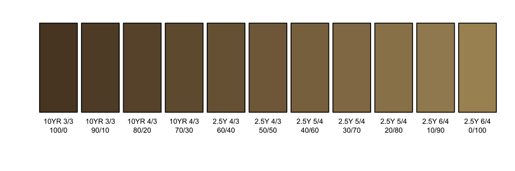

```r
s <- seq(from = 0, to = 100, by = 10)
colors <- c('10YR 3/3', '2.5Y 6/4')

z <- lapply(s, function(i) {

  wts <- c(100 - i, i)

  d <- cbind(
  parseMunsell(colors, convertColors=FALSE),
  parseMunsell(colors, return_triplets=TRUE, returnLAB=TRUE),
  pct = wts,
  col = parseMunsell(colors, convertColors=TRUE)
)

  mx <- estimateColorMixture(d, wt = 'pct', backTransform = TRUE)

  res <- data.frame(
    m.x = colors[1],
    m.y = colors[2],
    col.x = parseMunsell(colors[1]),
    col.y = parseMunsell(colors[2]),
    wt.x = wts[1],
    wt.y = wts[2],
    mixed.chip = sprintf('%s %s/%s', mx$colorhue, mx$colorvalue, mx$colorchroma),
    mixed.col = rgb(mx$r, mx$g, mx$b),
    stringsAsFactors = FALSE
  )

  res

  return(res)
})

z <- do.call('rbind', z)


par(mar = c(1,1,1,1))
plot(1:nrow(z), rep(1:nrow(z)), xlim = c(0.25, nrow(z) + 0.25), ylim = c(0, 0.8), axes = FALSE, xlab = '', ylab = '', type = 'n')

rect(xleft = (1:nrow(z)) - 0.45, xright = (1:nrow(z)) + 0.45, ybottom = 0.25, ytop = 0.75, col = z$mixed.col, border = 'black', lwd = 2, lend = 2)

text(1:nrow(z), 0.2, z$mixed.chip)
text(1:nrow(z), 0.15, sprintf('%s/%s', z$wt.x, z$wt.y))
```

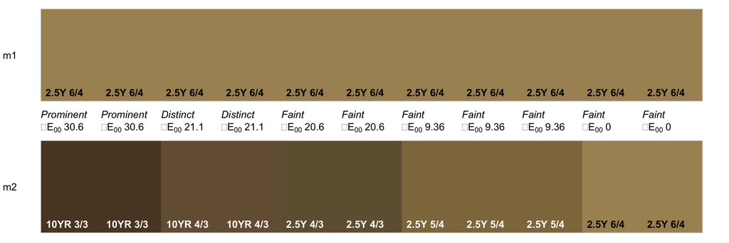

```r
colorContrastPlot(z$m.y, z$mixed.chip)
```

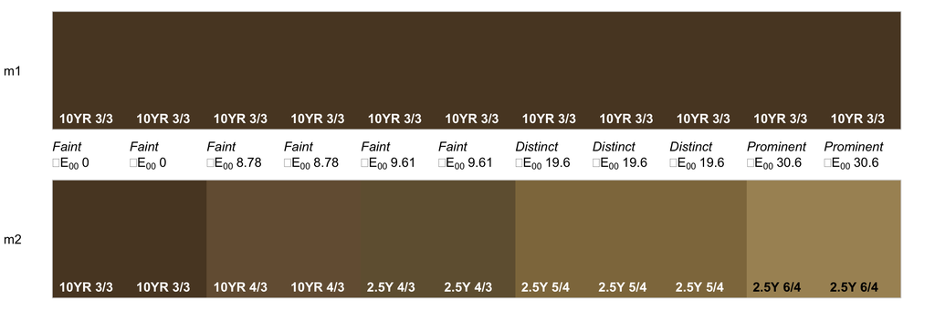

```r
colorContrastPlot(z$m.x, z$mixed.chip)
```

# Mix via Munsell Spectra

Hmmm, those colors look a little strange to me.

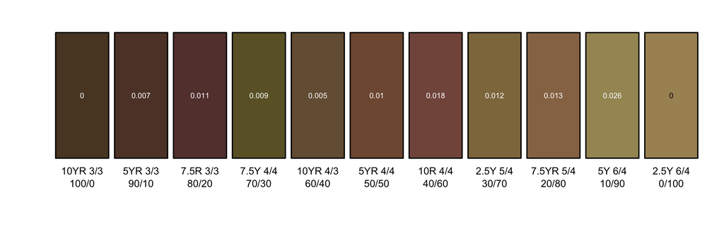

```r
s <- seq(from = 0, to = 100, by = 10)
colors <- c('10YR 3/3', '2.5Y 6/4')

z <- lapply(s, function(i) {

  wts <- c(100 - i, i)
  mx <- mixMunsell(colors, w = wts)

  d <- data.frame(
    m.x = colors[1],
    m.y = colors[2],
    col.x = parseMunsell(colors[1]),
    col.y = parseMunsell(colors[2]),
    wt.x = wts[1],
    wt.y = wts[2],
    mixed.chip = mx$munsell,
    mixed.col = parseMunsell(mx$munsell),
    dist = mx$distance,
    stringsAsFactors = FALSE
  )

  return(d)
})

z <- do.call('rbind', z)

par(mar = c(1,1,1,1))
plot(1:nrow(z), rep(1:nrow(z)), xlim = c(0.25, nrow(z) + 0.25), ylim = c(0, 0.8), axes = FALSE, xlab = '', ylab = '', type = 'n')

rect(xleft = (1:nrow(z)) - 0.45, xright = (1:nrow(z)) + 0.45, ybottom = 0.25, ytop = 0.75, col = z$mixed.col, border = 'black', lwd = 2, lend = 2)

text(1:nrow(z), 0.2, z$mixed.chip)
text(1:nrow(z), 0.15, sprintf('%s/%s', z$wt.x, z$wt.y))

text(1:nrow(z), 0.5, round(z$dist, 3), cex = 0.75, col = invertLabelColor(z$mixed.col))
```

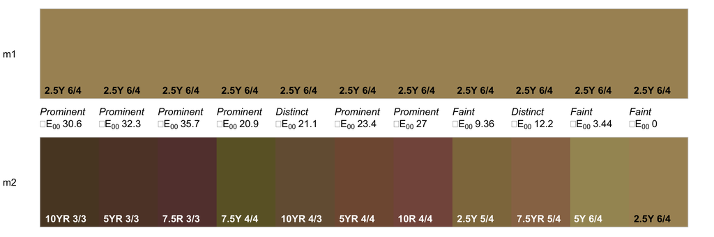

```r
colorContrastPlot(z$m.y, z$mixed.chip)
```

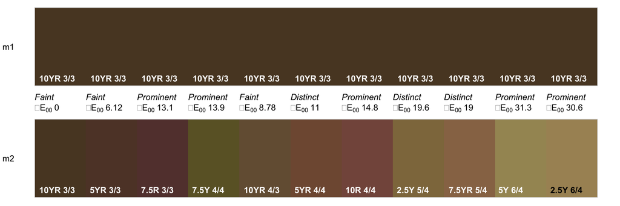

```r
colorContrastPlot(z$m.x, z$mixed.chip)
```

This document is based on `aqp` version 1.27 and `soilDB` version 2.5.9.